# Analisis Factorial de la escala percepción de la meritocracia y efecto del tratamiento experimental

# 3 Descriptivos

## 3.1 Tabla de descriptivos

```r
stargazer(pob_rec, type = "text")
```

```
##
## ===================================================================
## Statistic               N  Mean  St. Dev. Min Pctl(25) Pctl(75) Max
## -------------------------------------------------------------------
## perc_recom_esfuerzo    894 2.978  1.278    1     2        4      5
## perc_recom_talento     894 2.907  1.137    1     2        4      5
## perc_sal.adel_padr.ric 894 3.748  1.287    1     3        5      5
## perc_sal.adel_bue.cont 894 3.749  1.245    1     3        5      5
## para_surguir_fam.ric   894 2.461  1.213    1     2        3      5
## para_surguir_pa.educ   894 2.970  1.155    1     2        4      5
## para_surguir_ten.educ  894 4.065  0.869    1     3        5      5
## para_surguir_ten.ambi  894 3.594  1.025    1     3        4      5
## para_surguir_trab.duro 894 3.811  1.020    1     3        5      5
## norm_recom_esfuerzo    894 4.038  1.150    1     4        5      5
## norm_recom_talento     894 3.308  1.201    1     3        4      5
## norm_sal.adel_padr.ric 894 2.504  1.198    1     1        3      5
## norm_sal.adel_bue.cont 894 2.285  1.115    1     1        3      5
## t_trat                 894 0.336  0.472    0     0        1      1
## t_con                  894 0.339  0.474    0     0        1      1
## t_des                  894 0.326  0.469    0     0        1      1
## -------------------------------------------------------------------
```

En consideracion de estos descriptivos se debe decir que los casos peridos han sido eliminados correctamente, mientras que las variables parecen tener los rangos correspondientes. contamos con un n total de 894 sujetos, lo cual es suficiente para los analisis posteriores

## 3.2 Graficos descriptivos de las variables de percepción de meritocracia

```r
pob_mer[1:4] <-lapply(pob_mer[1:4],factor, levels = 1:5)
likt <- likert(pob_mer)
```

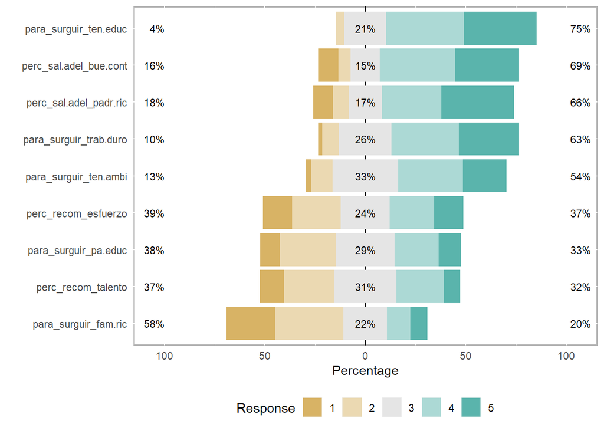

```r
plot(likt)
```

En primer lugar, la mayoría de las personas están de acuerdo con que para surgir es fundamental tener educación. La educación parece relacionarse con la idea de surgir o de elevarse en la escala social y por ello guardaría una relación con la noción de meritocracia, de hecho, en los análisis factoriales tiende a ser un factor junto a trabajar duro y tener ambición.

En segundo lugar, es interesante que las dos siguientes frases con mas acuerdo refieren a desigualdad de oportunidades, dando cuenta de una alta percepción de un contexto poco propicio para la meritocracia.

En tercer lugar, es llamativo que si bien la mayoría de los encuestados considera fundamental el tener ambición (54%) y el trabajo duro (63%) para surgir en la vida, están al mismo tiempo menos convencidos de que las personas que se esfuerzan más y tienen talento son más recompensadas. En consideración de esto y del alto grado de percepción de las desigualdades de oportunidad, puede decirse que hay una baja percepción de meritocracia, aunque se le consideran fundamentales los valores meritorios como estrategia de superación, lo que es coherente con el análisis de las variables normativas de meritocracia.

En último lugar, el hecho de que la frase con menor acuerdo sea “para surgir es necesario tener padres ricos” al mismo tiempo que hay un alto grado de acuerdo con que las personas con padres ricos logran salir adelante, sugiere que el término “para surgir” se relaciona más con ideales normativos, mientras que cuando se pregunta “En Chile las personas con padres ricos logran salir adelante” la gente lo interpreta más como percepción. Para evaluar este hipo tesis, hay que analizar la relación entre ambos modos de fraseo y las opiniones normativas